# R Notebook

XSectional

```r
library(brms)
library(readxl)
library(tidybayes)
library(ggplot2)
library(tidyr)
library(dplyr)
library(GGally)
library(ggpubr)
XSectional <- read_excel("DOD Priming Data Sheet_Wgender_May42020 (1).xlsx")
```

Drop variable in data set – One participant with hearing loss. One participant with unusable data because he was using half the sentence.

```r
XSectional %>%
  filter(drop==1)
```

| Part_No | Case_ID | Gender | Age | List | Item | Prime_verb | Trial_verb | Prime_type | Verb_match | Response | Ravens | PPVT | Notes | drop |
| --- | --- | --- | --- | --- | --- | --- | --- | --- | --- | --- | --- | --- | --- | --- |
| 75 | hp_01 | 1 | 8.720000 | 1 | 10 | brought | brought | 0.5 | 0.5 | NA | 30 | 131 | exp. error - slide did not play. | 1 |
| 76 | hp_02 | 0 | 5.810000 | 2 | 2r | brought | showed | -0.5 | -0.5 | NA | 25 | 100 | did not repeat trial verb | 1 |
| 76 | hp_02 | 0 | 5.810000 | 2 | 4r | showed | showed | 0.5 | 0.5 | NA | 25 | 100 | did not repeat trial verb | 1 |
| 85 | lm_11 | 1 | 4.400000 | 3 | 2 | showed | brought | -0.5 | -0.5 | 1 | 14 | 87 | Exp error | 1 |
| 85 | lm_11 | 1 | 4.400000 | 3 | 4 | showed | showed | 0.5 | 0.5 | 1 | 14 | 87 | Exp error | 1 |
| 86 | cv_12 | 1 | 4.600000 | 4 | 2r | brought | showed | -0.5 | -0.5 | 0 | 15 | 79 | Exp error | 1 |
| 86 | cv_12 | 1 | 4.600000 | 4 | 3r | threw | threw | 0.5 | 0.5 | 0 | 15 | 79 | Exp error | 1 |
| 90 | cv_16 | 1 | 4.370000 | 8 | 3r | threw | threw | -0.5 | 0.5 | 0 | 12 | 92 | DOD on first response but wrong verb/ After re-promting with sentence start responded POD | 1 |
| 92 | cv_18 | 1 | 4.350000 | 2 | 9r | passed | sent | 0.5 | -0.5 | 0 | 16 | 86 | inserted own verb/ completed sentence afterwards | 1 |
| 95 | stm_02 | 1 | 7.630000 | 5 | 2 | showed | brought | -0.5 | -0.5 | 0 | 20 | 143 | *participant responded with "passed" as target verb before exp. prompt with intended verb | 1 |

[output cut: 71 more lines]

```r
NA
```

```r
XSectional <- subset(XSectional, drop != 1)
```

```r
table(XSectional$Notes)
```

```
                   *regularly speaks Croatian at home             called princess 'Cinderella' (consistent)
                                                    1                                                     1
couldn’t tell what object was - experimenter prompted                           prompted to finish sentence
                                                    1                                                     2
                                repetition/stuttering                    replay/ lots of prompting to begin
                                                    1                                                     1
         replayed first clip - no response first time                       storytelling surrounding answer
                                                    1                                                     1
```

```r
XSectional %>%
  filter(!is.na(Response) & !is.na(Notes))
```

| Part_No | Case_ID | Gender | Age | List | Item | Prime_verb | Trial_verb | Prime_type | Verb_match | Response | Ravens | PPVT | Notes | drop |
| --- | --- | --- | --- | --- | --- | --- | --- | --- | --- | --- | --- | --- | --- | --- |
| 89 | cv_15 | 1 | 4.990000 | 7 | 5 | brought | threw | 0.5 | -0.5 | 0 | 19 | 96 | called princess 'Cinderella' (consistent) | 0 |
| 92 | cv_18 | 1 | 4.350000 | 2 | 1r | passed | passed | -0.5 | 0.5 | 0 | 16 | 86 | replay/ lots of prompting to begin | 0 |
| 92 | cv_18 | 1 | 4.350000 | 2 | 4r | showed | showed | 0.5 | 0.5 | 0 | 16 | 86 | repetition/stuttering | 0 |
| 109 | stm_08 | 1 | 7.640000 | 3 | 1 | passed | passed | 0.5 | 0.5 | 1 | 25 | 142 | *regularly speaks Croatian at home | 0 |
| 140 | llab_11 | 1 | 3.600274 | 3 | 1 | passed | passed | 0.5 | 0.5 | 0 | NA | 91 | replayed first clip - no response first time | 0 |
| 141 | llab_12 | 1 | 3.956194 | 4 | 4r | showed | showed | -0.5 | 0.5 | 0 | NA | 95 | couldn’t tell what object was - experimenter prompted | 0 |
| 142 | llab_13 | 1 | 3.797399 | 5 | 1 | passed | passed | -0.5 | 0.5 | 0 | NA | 77 | prompted to finish sentence | 0 |
| 142 | llab_13 | 1 | 3.797399 | 5 | 11 | sent | sent | -0.5 | 0.5 | 0 | NA | 77 | prompted to finish sentence | 0 |
| 146 | llab_17 | 0 | 3.258042 | 1 | 9 | sent | passed | 0.5 | -0.5 | 0 | NA | 70 | storytelling surrounding answer | 0 |

First we’ll get some descriptives on some between subjects variables.

```r
XSectional %>%
  group_by(Part_No) %>%
  slice(1) %>%
  ungroup() %>%
  select("Age", "PPVT", "Ravens") %>%
  get_summary_stats(type="common")
```

| variable | n | min | max | median | iqr | mean | sd | se | ci |
| --- | --- | --- | --- | --- | --- | --- | --- | --- | --- |
| Age | 140 | 3.258 | 8.72 | 5.936 | 2.203 | 5.957 | 1.313 | 0.111 | 0.219 |
| PPVT | 140 | 10.000 | 158.00 | 118.500 | 39.000 | 115.643 | 25.594 | 2.163 | 4.277 |
| Ravens | 132 | 9.000 | 35.00 | 21.000 | 11.000 | 21.439 | 6.563 | 0.571 | 1.130 |

```r
NA
```

Look at marginal and conditional distributions for each.

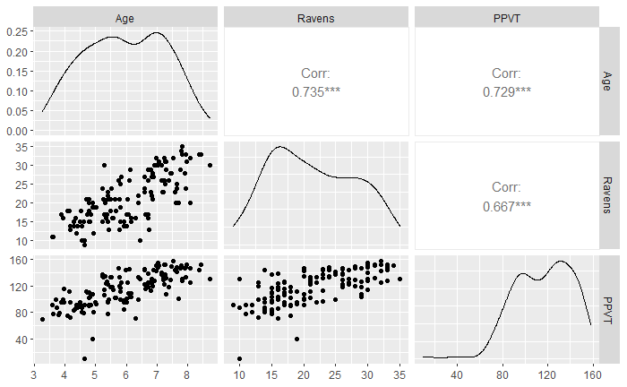

```r
XSectional %>%
  group_by(Part_No) %>%
  slice(1) %>%
  ungroup() %>%
  select(Age, Ravens, PPVT) %>%
  ggpairs()
```

```r
XSectional <- XSectional %>%
 mutate(
    Prime = ifelse(Prime_type==.5, yes="DOD", no="POD"),
    Overlap = ifelse(Verb_match==.5, yes="No Overal", no="Overlap")
    )


XSectional  %>%
  group_by(Prime, Trial_verb) %>%
  summarise( n = n()
             )
```

| Prime | Trial_verb | n |
| --- | --- | --- |
| DOD | brought | 136 |
| DOD | gave | 140 |
| DOD | passed | 140 |
| DOD | sent | 137 |
| DOD | showed | 136 |
| DOD | threw | 140 |
| POD | brought | 138 |
| POD | gave | 140 |
| POD | passed | 138 |
| POD | sent | 139 |

[output cut: 2 more lines]

```r
XSectional  %>%
  group_by(Overlap, Trial_verb) %>%
   summarise(
    n = n()
  )
```

| Overlap | Trial_verb | n |
| --- | --- | --- |
| No Overal | brought | 138 |
| No Overal | gave | 140 |
| No Overal | passed | 140 |
| No Overal | sent | 139 |
| No Overal | showed | 137 |
| No Overal | threw | 138 |
| Overlap | brought | 136 |
| Overlap | gave | 140 |
| Overlap | passed | 138 |
| Overlap | sent | 137 |

[output cut: 2 more lines]

```r
XSectional %>%
  group_by(Item) %>%
   summarise(
    n = n()
  )
```

| Item | n |
| --- | --- |
| 1 | 72 |
| 10 | 70 |
| 10r | 68 |
| 11 | 71 |
| 11r | 68 |
| 12 | 72 |
| 12r | 67 |
| 1r | 68 |
| 2 | 68 |
| 2r | 65 |

[output cut: 14 more lines]

```r
XSectional %>%
  group_by(List) %>%
   summarise(
    n = n()
  )
```

| List | n |
| --- | --- |
| 1 | 238 |
| 2 | 201 |
| 3 | 202 |
| 4 | 201 |
| 5 | 199 |
| 6 | 228 |
| 7 | 212 |
| 8 | 178 |

Recoding, etc

```r
XSectional$bias <-"DOD"

XSectional %>%
  group_by(Trial_verb) %>%
  summarise(mean = mean(Response, na.rm=TRUE))
```

| Trial_verb | mean |
| --- | --- |
| brought | 0.2481752 |
| gave | 0.3678571 |
| passed | 0.1942446 |
| sent | 0.1449275 |
| showed | 0.4065934 |
| threw | 0.1366906 |

```r
XSectional$bias[XSectional$Prime_verb=="passed"] = "POD"
XSectional$bias[XSectional$Prime_verb=="sent"] = "POD"
XSectional$bias[XSectional$Prime_verb=="threw"] = "POD"
```

```r
XSectional$Bias_POD <- ifelse(XSectional$bias=="POD", yes = .5, no=-.5 )
```

```r
XSectional$biasmatch <-"match"

XSectional$biasmatch[XSectional$bias=="POD" & XSectional$Prime == "DOD"] = "mismatch"
XSectional$biasmatch[XSectional$bias=="DOD" & XSectional$Prime == "POD"] = "mismatch"

table(XSectional$biasmatch)
```

```
   match mismatch
     827      832
```

```r
XSectional$biasmismatchc <- ifelse(XSectional$biasmatch == "mismatch", yes=.5, no=-.5)
```

Vocab and PPVT both increase with age. Also there are some prett serious outliers on the PPVT

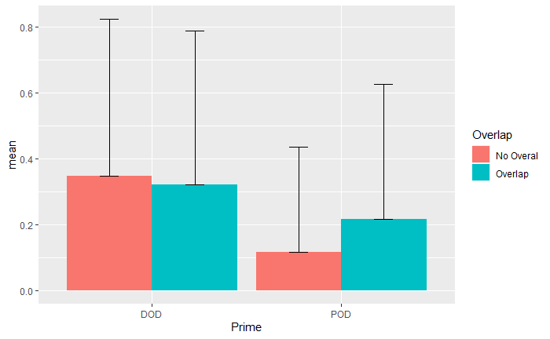

```r
XSectional %>%
  group_by(Prime, Overlap) %>%
  summarise(mean = mean(Response, na.rm=TRUE),
            sd = sd(Response, na.rm=TRUE)) %>%

ggplot(aes(y=mean, x=Prime, fill=Overlap)) +
  geom_bar(stat="identity",position="dodge") +
 geom_errorbar(aes(ymin=mean, ymax=mean+sd), width=.2,
                 position=position_dodge(.9))
```

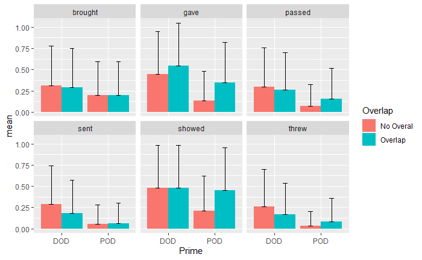

```r
XSectional %>%
  group_by(Prime, Overlap, Trial_verb) %>%
  summarise(mean = mean(Response, na.rm=TRUE),
            sd = sd(Response, na.rm=TRUE)) %>%

ggplot(aes(y=mean, x=Prime, fill=Overlap)) +
  geom_bar(stat="identity",position="dodge") +
 geom_errorbar(aes(ymin=mean, ymax=mean+sd), width=.2,
                 position=position_dodge(.9)) +
  facet_wrap(~Trial_verb)
```

```r
logit_prior = c(prior(normal(0,2), class=sd))
```

On to look at some variance components.

```r
m1 <- brm(Response ~ 1 + (1 | Case_ID) + (1 | Trial_verb) + (1 | Case_ID:Trial_verb), logit_prior, family="bernoulli", iter=4000, cores=4, data=XSectional, file="m1")
```

```r
summary(m1)
```

```
 Family: bernoulli
  Links: mu = logit
Formula: Response ~ 1 + (1 | Case_ID) + (1 | Trial_verb) + (1 | Case_ID:Trial_verb)
   Data: XSectional (Number of observations: 1659)
Samples: 4 chains, each with iter = 4000; warmup = 2000; thin = 1;
         total post-warmup samples = 8000

Group-Level Effects:
~Case_ID (Number of levels: 140)
              Estimate Est.Error l-95% CI u-95% CI Rhat Bulk_ESS Tail_ESS
sd(Intercept)     1.52      0.15     1.25     1.82 1.00     2654     4321

~Case_ID:Trial_verb (Number of levels: 838)
              Estimate Est.Error l-95% CI u-95% CI Rhat Bulk_ESS Tail_ESS
sd(Intercept)     0.21      0.15     0.01     0.57 1.01     1263     2321

~Trial_verb (Number of levels: 6)
              Estimate Est.Error l-95% CI u-95% CI Rhat Bulk_ESS Tail_ESS
sd(Intercept)     1.05      0.42     0.52     2.15 1.00     2330     3392

Population-Level Effects:
          Estimate Est.Error l-95% CI u-95% CI Rhat Bulk_ESS Tail_ESS
Intercept    -1.58      0.47    -2.49    -0.59 1.00     1530     2682

Samples were drawn using sampling(NUTS). For each parameter, Bulk_ESS
and Tail_ESS are effective sample size measures, and Rhat is the potential
scale reduction factor on split chains (at convergence, Rhat = 1).
```

Fit a simpler model without the interacton between participant and trial.

```r
m1b <- brm(Response ~ 1 + (1 | Case_ID) + (1 | Trial_verb), logit_prior, family="bernoulli", iter=4000, cores=4, data=XSectional, file="m1b")
```

```r
summary(m1b)
```

```
 Family: bernoulli
  Links: mu = logit
Formula: Response ~ 1 + (1 | Case_ID) + (1 | Trial_verb)
   Data: XSectional (Number of observations: 1659)
Samples: 4 chains, each with iter = 4000; warmup = 2000; thin = 1;
         total post-warmup samples = 8000

Group-Level Effects:
~Case_ID (Number of levels: 140)
              Estimate Est.Error l-95% CI u-95% CI Rhat Bulk_ESS Tail_ESS
sd(Intercept)     1.50      0.15     1.24     1.81 1.00     2689     4474

~Trial_verb (Number of levels: 6)
              Estimate Est.Error l-95% CI u-95% CI Rhat Bulk_ESS Tail_ESS
sd(Intercept)     1.05      0.43     0.52     2.12 1.00     2503     3664

Population-Level Effects:
          Estimate Est.Error l-95% CI u-95% CI Rhat Bulk_ESS Tail_ESS
Intercept    -1.52      0.46    -2.41    -0.57 1.01     1812     2854

Samples were drawn using sampling(NUTS). For each parameter, Bulk_ESS
and Tail_ESS are effective sample size measures, and Rhat is the potential
scale reduction factor on split chains (at convergence, Rhat = 1).
```

```r
m1<- add_criterion(m1, "loo")
m1b<- add_criterion(m1b, "loo")
```

```r
loo_compare(m1, m1b)
```

```
    elpd_diff se_diff
m1b  0.0       0.0
m1  -0.6       0.5
```

```r
model_weights(m1, m1b)
```

```
Some Pareto k diagnostic values are slightly high. See help('pareto-k-diagnostic') for details.
Some Pareto k diagnostic values are slightly high. See help('pareto-k-diagnostic') for details.
```

```
          m1          m1b
2.733350e-06 9.999973e-01
```

M1b is favored over m1. This difference is not greater than 2 standard errors, but I think the given that the added complexity of the part X item random effects isn’t adding anything in the this case, then it’s not worth the extra interpretational complexity when the other covariates are added.

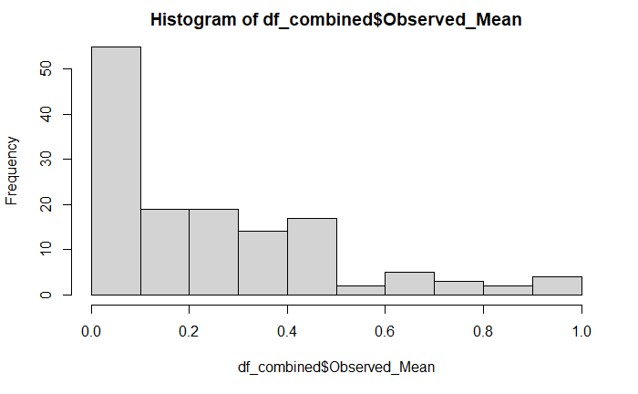

```r
df <- m1b %>%
  spread_draws(b_Intercept, r_Case_ID[Case_ID,Intercept])

df <- df %>%
  mutate(
    Part_Mean = inv_logit_scaled(b_Intercept + r_Case_ID)
  )

df_part <- df %>%
  group_by(Case_ID) %>%
  summarise(
    Predict_Mean = mean(Part_Mean),
    Predict_SD = sd(Part_Mean)
  )

df_raw_part <- XSectional %>%
  group_by(Case_ID) %>%
  summarise(
    Observed_Mean = mean(Response, na.rm=TRUE)
  )

df_combined <- merge(df_part, df_raw_part, by="Case_ID")

hist(df_combined$Observed_Mean)
```

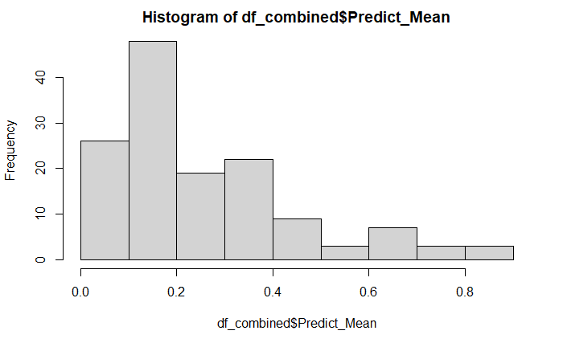

```r
hist(df_combined$Predict_Mean )
```

```r
XSectional2 <- merge(XSectional, df_raw_part, by="Case_ID")
```

Drop participants with no DODs.

```r
XSectional2 <- subset(XSectional2, Observed_Mean != 0)
```

```r
XSectional$Agec = XSectional$Age - mean(XSectional$Age)
```

```r
m2 <- brm(Response ~ 1 + Prime_type*Verb_match*Agec + (1 + Prime_type*Verb_match| Case_ID) + (1 + Prime_type*Verb_match*Agec | Trial_verb), logit_prior, family="bernoulli", iter=10000, cores=4, save_all_pars=TRUE,  data=XSectional, file="m2")
```

```r
summary(m2)
```

```
There were 5 divergent transitions after warmup. Increasing adapt_delta above 0.8 may help. See http://mc-stan.org/misc/warnings.html#divergent-transitions-after-warmup
```

```
 Family: bernoulli
  Links: mu = logit
Formula: Response ~ 1 + Prime_type * Verb_match * Agec + (1 + Prime_type * Verb_match | Case_ID) + (1 + Prime_type * Verb_match * Agec | Trial_verb)
   Data: XSectional (Number of observations: 1659)
Samples: 4 chains, each with iter = 10000; warmup = 5000; thin = 1;
         total post-warmup samples = 20000

Group-Level Effects:
~Case_ID (Number of levels: 140)
                                      Estimate Est.Error l-95% CI u-95% CI Rhat Bulk_ESS Tail_ESS
sd(Intercept)                             1.81      0.18     1.48     2.19 1.00     6018    10649
sd(Prime_type)                            0.68      0.36     0.05     1.39 1.00     3386     5370
sd(Verb_match)                            0.31      0.22     0.01     0.82 1.00     6923     6907
sd(Prime_type:Verb_match)                 0.72      0.50     0.03     1.85 1.00     5092     8129
cor(Intercept,Prime_type)                -0.31      0.33    -0.83     0.46 1.00    12503     8370
cor(Intercept,Verb_match)                 0.19      0.42    -0.70     0.86 1.00    19417    14160
cor(Prime_type,Verb_match)               -0.08      0.44    -0.84     0.77 1.00    14993    14417
cor(Intercept,Prime_type:Verb_match)      0.02      0.40    -0.75     0.76 1.00    20601    13574
cor(Prime_type,Prime_type:Verb_match)     0.13      0.43    -0.74     0.85 1.00    10624    13881
cor(Verb_match,Prime_type:Verb_match)    -0.00      0.45    -0.81     0.81 1.00    11209    15773

~Trial_verb (Number of levels: 6)
                                                      Estimate Est.Error l-95% CI u-95% CI Rhat Bulk_ESS Tail_ESS
sd(Intercept)                                             1.28      0.47     0.67     2.48 1.00     7337    11316
sd(Prime_type)                                            0.76      0.43     0.12     1.82 1.00     7059     7474
sd(Verb_match)                                            0.56      0.36     0.05     1.47 1.00     7287     6950
sd(Agec)                                                  0.19      0.17     0.01     0.61 1.00     7071     9060
sd(Prime_type:Verb_match)                                 0.63      0.53     0.03     1.99 1.00     9429    10845
sd(Prime_type:Agec)                                       0.25      0.24     0.01     0.87 1.00     8760    10263
sd(Verb_match:Agec)                                       0.76      0.36     0.29     1.70 1.00    11383    12736
sd(Prime_type:Verb_match:Agec)                            0.49      0.43     0.02     1.62 1.00     9879    10227
cor(Intercept,Prime_type)                                -0.25      0.30    -0.76     0.37 1.00    16315    13970
cor(Intercept,Verb_match)                                -0.21      0.31    -0.75     0.44 1.00    19555    14283
cor(Prime_type,Verb_match)                                0.03      0.32    -0.58     0.63 1.00    19404    15888
cor(Intercept,Agec)                                      -0.01      0.32    -0.62     0.61 1.00    22740    14302
cor(Prime_type,Agec)                                     -0.03      0.33    -0.64     0.59 1.00    19586    15612
cor(Verb_match,Agec)                                     -0.02      0.33    -0.64     0.61 1.00    17903    16116
cor(Intercept,Prime_type:Verb_match)                     -0.04      0.33    -0.66     0.59 1.00    24883    14382
cor(Prime_type,Prime_type:Verb_match)                     0.04      0.33    -0.60     0.66 1.00    21848    15603
cor(Verb_match,Prime_type:Verb_match)                    -0.03      0.33    -0.65     0.61 1.00    19340    16332
```

[output cut: 19 more lines]

```

Population-Level Effects:
                           Estimate Est.Error l-95% CI u-95% CI Rhat Bulk_ESS Tail_ESS
Intercept                     -1.92      0.57    -3.04    -0.74 1.00     4916     8305
Prime_type                     1.83      0.44     1.02     2.77 1.00     7321    10267
Verb_match                    -0.53      0.33    -1.17     0.15 1.00     8972     9293
Agec                           0.48      0.17     0.14     0.82 1.00     6344     9515
Prime_type:Verb_match          1.39      0.52     0.38     2.47 1.00    12241    11589
Prime_type:Agec               -0.15      0.21    -0.55     0.24 1.00    11750     9743
Verb_match:Agec                0.04      0.36    -0.70     0.78 1.00    10602    11099
Prime_type:Verb_match:Agec     0.12      0.38    -0.61     0.87 1.00    15341    13238

Samples were drawn using sampling(NUTS). For each parameter, Bulk_ESS
and Tail_ESS are effective sample size measures, and Rhat is the potential
scale reduction factor on split chains (at convergence, Rhat = 1).
```

```r
hypothesis(m2, "Prime_type:Verb_match:Agec < 0")
```

```
Hypothesis Tests for class b:
```

| Hypothesis | Estimate | Est.Error | CI.Lower | CI.Upper | Evid.Ratio | Post.Prob | Star |
| --- | --- | --- | --- | --- | --- | --- | --- |
| (Prime_type:Verb_... < 0 | 0.12 | 0.38 | -0.46 | 0.71 | 0.57 | 0.36 |  |

```
---
'CI': 90%-CI for one-sided and 95%-CI for two-sided hypotheses.
'*': For one-sided hypotheses, the posterior probability exceeds 95%;
for two-sided hypotheses, the value tested against lies outside the 95%-CI.
Posterior probabilities of point hypotheses assume equal prior probabilities.
```

```r
hypothesis(m2, "Prime_type:Agec < 0")
```

```
Hypothesis Tests for class b:
```

| Hypothesis | Estimate | Est.Error | CI.Lower | CI.Upper | Evid.Ratio | Post.Prob | Star |
| --- | --- | --- | --- | --- | --- | --- | --- |
| (Prime_type:Agec) < 0 | -0.15 | 0.21 | -0.47 | 0.16 | 4.13 | 0.81 |  |

```
---
'CI': 90%-CI for one-sided and 95%-CI for two-sided hypotheses.
'*': For one-sided hypotheses, the posterior probability exceeds 95%;
for two-sided hypotheses, the value tested against lies outside the 95%-CI.
Posterior probabilities of point hypotheses assume equal prior probabilities.
```

```r
hypothesis(m2, "Prime_type:Verb_match > 0")
```

```
Hypothesis Tests for class b:
```

| Hypothesis | Estimate | Est.Error | CI.Lower | CI.Upper | Evid.Ratio | Post.Prob | Star |
| --- | --- | --- | --- | --- | --- | --- | --- |
| (Prime_type:Verb_... > 0 | 1.39 | 0.52 | 0.58 | 2.24 | 130.58 | 0.99 | * |

```
---
'CI': 90%-CI for one-sided and 95%-CI for two-sided hypotheses.
'*': For one-sided hypotheses, the posterior probability exceeds 95%;
for two-sided hypotheses, the value tested against lies outside the 95%-CI.
Posterior probabilities of point hypotheses assume equal prior probabilities.
```

```r
hypothesis(m2, "Prime_type:Agec < 0")
```

```
Hypothesis Tests for class b:
```

| Hypothesis | Estimate | Est.Error | CI.Lower | CI.Upper | Evid.Ratio | Post.Prob | Star |
| --- | --- | --- | --- | --- | --- | --- | --- |
| (Prime_type:Agec) < 0 | -0.15 | 0.21 | -0.47 | 0.16 | 4.13 | 0.81 |  |

```
---
'CI': 90%-CI for one-sided and 95%-CI for two-sided hypotheses.
'*': For one-sided hypotheses, the posterior probability exceeds 95%;
for two-sided hypotheses, the value tested against lies outside the 95%-CI.
Posterior probabilities of point hypotheses assume equal prior probabilities.
```

[figure not shown]

```r
m2_fitted_logit <- fitted(m2, re_formula=NA, scale="linear") %>%
  cbind(XSectional) %>%
  dplyr::select(Age, Prime, Overlap, Estimate, Q2.5, Q97.5) %>%
  ggplot(aes(y=Estimate, ymin=Q2.5, ymax=Q97.5, x=Age, fill=Prime, line=Prime)) + geom_point() + geom_line() +  geom_ribbon(alpha=0.5) + facet_wrap(~Overlap) + labs(y="Linear Predictor") + theme(axis.title.x=element_blank(),
        axis.text.x=element_blank(),
        axis.ticks.x=element_blank())

m2_fitted_response <- fitted(m2, re_formula=NA, scale="response") %>%
  cbind(XSectional) %>%
  dplyr::select(Age, Prime, Overlap, Estimate, Q2.5, Q97.5) %>%
  ggplot(aes(y=Estimate, ymin=Q2.5, ymax=Q97.5, x=Age, fill=Prime, line=Prime)) + geom_point() + geom_line() +  geom_ribbon(alpha=0.5) + facet_wrap(~Overlap) + labs(y="Probability")  +
theme(
  strip.background = element_blank(),
  strip.text.x = element_blank()
)


m2_fitted_logit/m2_fitted_response + plot_layout(guides = "collect") & theme(legend.position = "right")
```

Note that in the model above, I included correlated random effects. It took forever to run, and I essentially got the prior back for most of those correlations (modes of 0 with really large errors). I’m going to fit the model again with uncorrelated random effects, to make sure I get comparable results.

```r
m2b <- brm(Response ~ 1 + Prime_type*Verb_match*Agec + (1 + Prime_type*Verb_match|| Case_ID) + (1 + Prime_type*Verb_match*Agec || Trial_verb), logit_prior, family="bernoulli", iter=10000, cores=4, save_all_pars=TRUE,  data=XSectional, file="m2b")
```

```r
summary(m2b)
```

[output not shown]

```r
hypothesis(m2b, "Prime_type:Verb_match:Agec < 0")
hypothesis(m2b, "Prime_type:Agec < 0")
hypothesis(m2b, "Prime_type:Verb_match > 0")
```

[output not shown]

```r
m3 <- brm(Response ~ 1 + Prime_type*Verb_match*Agec + (1 + Prime_type*Verb_match| Case_ID) + (1 + Prime_type*Verb_match*Agec | Trial_verb), logit_prior, family="bernoulli", iter=10000, cores=4, save_all_pars=TRUE,  data=XSectional, file="m3")
```

[output not shown]

```r
summary(m3)
```

```
There were 13 divergent transitions after warmup. Increasing adapt_delta above 0.8 may help. See http://mc-stan.org/misc/warnings.html#divergent-transitions-after-warmup
```

```
 Family: bernoulli
  Links: mu = logit
Formula: Response ~ 1 + Prime_type * Verb_match * Agec + (1 + Prime_type * Verb_match | Case_ID) + (1 + Prime_type * Verb_match * Agec | Trial_verb)
   Data: XSectional (Number of observations: 1659)
Samples: 4 chains, each with iter = 10000; warmup = 5000; thin = 1;
         total post-warmup samples = 20000

Group-Level Effects:
~Case_ID (Number of levels: 140)
                                      Estimate Est.Error l-95% CI u-95% CI Rhat Bulk_ESS Tail_ESS
sd(Intercept)                             1.81      0.18     1.48     2.19 1.00     5763    11456
sd(Prime_type)                            0.68      0.36     0.05     1.38 1.00     3681     5939
sd(Verb_match)                            0.30      0.22     0.01     0.82 1.00     6666     9154
sd(Prime_type:Verb_match)                 0.72      0.50     0.03     1.85 1.00     5481     8640
cor(Intercept,Prime_type)                -0.30      0.32    -0.83     0.46 1.00    13870    10291
cor(Intercept,Verb_match)                 0.18      0.42    -0.70     0.86 1.00    19898    14104
cor(Prime_type,Verb_match)               -0.07      0.44    -0.83     0.77 1.00    16709    14465
cor(Intercept,Prime_type:Verb_match)      0.02      0.40    -0.75     0.77 1.00    20876    13125
cor(Prime_type,Prime_type:Verb_match)     0.13      0.43    -0.74     0.85 1.00    11549    14858
cor(Verb_match,Prime_type:Verb_match)    -0.00      0.44    -0.81     0.81 1.00    12964    15990

~Trial_verb (Number of levels: 6)
                                                      Estimate Est.Error l-95% CI u-95% CI Rhat Bulk_ESS Tail_ESS
sd(Intercept)                                             1.28      0.49     0.66     2.53 1.00     7249    10202
sd(Prime_type)                                            0.75      0.43     0.11     1.82 1.00     6610     6960
sd(Verb_match)                                            0.57      0.38     0.05     1.51 1.00     7432     7109
sd(Agec)                                                  0.20      0.17     0.01     0.66 1.00     6655     9867
sd(Prime_type:Verb_match)                                 0.63      0.52     0.02     1.95 1.00     9701    10357
sd(Prime_type:Agec)                                       0.25      0.24     0.01     0.85 1.00     9382     9807
sd(Verb_match:Agec)                                       0.77      0.37     0.29     1.73 1.00    10601    12344
sd(Prime_type:Verb_match:Agec)                            0.49      0.43     0.02     1.60 1.00     9384    10916
cor(Intercept,Prime_type)                                -0.24      0.30    -0.75     0.38 1.00    17760    14651
cor(Intercept,Verb_match)                                -0.22      0.31    -0.75     0.43 1.00    19007    14783
cor(Prime_type,Verb_match)                                0.03      0.32    -0.58     0.63 1.00    19083    14875
cor(Intercept,Agec)                                      -0.01      0.31    -0.60     0.59 1.00    24288    15552
cor(Prime_type,Agec)                                     -0.03      0.33    -0.63     0.60 1.00    21834    16297
cor(Verb_match,Agec)                                     -0.02      0.33    -0.64     0.61 1.00    17305    16629
cor(Intercept,Prime_type:Verb_match)                     -0.04      0.33    -0.65     0.59 1.00    22704    12866
cor(Prime_type,Prime_type:Verb_match)                     0.04      0.33    -0.60     0.66 1.00    21012    15797
cor(Verb_match,Prime_type:Verb_match)                    -0.03      0.33    -0.66     0.61 1.00    19802    15406
```

[output cut: 19 more lines]

```

Population-Level Effects:
                           Estimate Est.Error l-95% CI u-95% CI Rhat Bulk_ESS Tail_ESS
Intercept                     -1.91      0.58    -3.03    -0.69 1.00     5710     8347
Prime_type                     1.83      0.44     1.02     2.78 1.00     7769     9515
Verb_match                    -0.53      0.34    -1.21     0.17 1.00     9102    10309
Agec                           0.47      0.18     0.13     0.82 1.00     6351     9515
Prime_type:Verb_match          1.39      0.51     0.40     2.44 1.00    14224    11878
Prime_type:Agec               -0.15      0.20    -0.55     0.24 1.00    11385    10123
Verb_match:Agec                0.03      0.37    -0.71     0.80 1.00    10402     9641
Prime_type:Verb_match:Agec     0.12      0.38    -0.64     0.88 1.00    13308    10707

Samples were drawn using sampling(NUTS). For each parameter, Bulk_ESS
and Tail_ESS are effective sample size measures, and Rhat is the potential
scale reduction factor on split chains (at convergence, Rhat = 1).
```

```r
hypothesis(m3, "Prime_type:Verb_match:Agec < 0")
```

```
Hypothesis Tests for class b:
```

| Hypothesis | Estimate | Est.Error | CI.Lower | CI.Upper | Evid.Ratio | Post.Prob | Star |
| --- | --- | --- | --- | --- | --- | --- | --- |
| (Prime_type:Verb_... < 0 | 0.12 | 0.38 | -0.48 | 0.71 | 0.58 | 0.37 |  |

```
---
'CI': 90%-CI for one-sided and 95%-CI for two-sided hypotheses.
'*': For one-sided hypotheses, the posterior probability exceeds 95%;
for two-sided hypotheses, the value tested against lies outside the 95%-CI.
Posterior probabilities of point hypotheses assume equal prior probabilities.
```

```r
hypothesis(m3, "Prime_type:Agec < 0")
```

```
Hypothesis Tests for class b:
```

| Hypothesis | Estimate | Est.Error | CI.Lower | CI.Upper | Evid.Ratio | Post.Prob | Star |
| --- | --- | --- | --- | --- | --- | --- | --- |
| (Prime_type:Agec) < 0 | -0.15 | 0.2 | -0.47 | 0.16 | 4.13 | 0.8 |  |

```
---
'CI': 90%-CI for one-sided and 95%-CI for two-sided hypotheses.
'*': For one-sided hypotheses, the posterior probability exceeds 95%;
for two-sided hypotheses, the value tested against lies outside the 95%-CI.
Posterior probabilities of point hypotheses assume equal prior probabilities.
```

```r
hypothesis(m3, "Prime_type:Verb_match > 0")
```

```
Hypothesis Tests for class b:
```

| Hypothesis | Estimate | Est.Error | CI.Lower | CI.Upper | Evid.Ratio | Post.Prob | Star |
| --- | --- | --- | --- | --- | --- | --- | --- |
| (Prime_type:Verb_... > 0 | 1.39 | 0.51 | 0.59 | 2.23 | 159 | 0.99 | * |

```
---
'CI': 90%-CI for one-sided and 95%-CI for two-sided hypotheses.
'*': For one-sided hypotheses, the posterior probability exceeds 95%;
for two-sided hypotheses, the value tested against lies outside the 95%-CI.
Posterior probabilities of point hypotheses assume equal prior probabilities.
```

Refit model 2 with informative prior for bayes factor.

```r
logit_prior2= c(prior(normal(0,2), class=sd),
                 prior(normal(.45, .15), coef="Prime_type:Verb_match:Agec"))
```

```r
m2_alt <- brm(Response ~ 1 + Prime_type*Verb_match*Agec + (1 + Prime_type*Verb_match|| Case_ID) + (1 + Prime_type*Verb_match*Agec || Trial_verb), logit_prior2, family="bernoulli", iter=30000, cores=4, save_all_pars=TRUE, sample_prior="yes", data=XSectional)
```

```r
summary(m2b)
```

[output not shown]

```r
hypothesis(m2b, "Prime_type:Verb_match:Agec = 0")
```

[output not shown]

```r
logit_prior3= c(prior(normal(0,2), class=sd),
                 prior(normal(0, .05), coef="Prime_type:Verb_match:Agec"))
```

```r
m2_null <- brm(Response ~ 1 +Prime_type*Verb_match*Agec  + (1 + Prime_type*Verb_match|| Case_ID) + (1 + Prime_type*Verb_match*Agec || Trial_verb), logit_prior3, family="bernoulli", iter=30000, cores=4, save_all_pars=TRUE, sample_prior="yes", data=XSectional)
```

```r
bayes_factor(m2b, m2c)
bayes_factor(m2b, m2c)
bayes_factor(m2b, m2c)
```

[output not shown]

Repeat this a few times to make sure we get the same answer

```r
bayes_factor(m2, m2c )
bayes_factor(m2, m2c )
bayes_factor(m2, m2c )
```

[output not shown]

```r
bayes_factor(m2, m2b)
bayes_factor(m2, m2b)
bayes_factor(m2, m2b)
```

[output not shown]

```r
m3 <- brm(Response ~ 1 + Prime_type + Verb_match + Prime_type*Bias_POD*Agec + (1 + Prime_type + Verb_match + Prime_type*Bias_POD || Case_ID) + (1 +Prime_type + Verb_match + Prime_type*Bias_POD*Agec  || Trial_verb), logit_prior, family="bernoulli", save_all_pars=TRUE, iter=10000, cores=4, data=XSectional)
```

```r
summary(m3)
```

[output not shown]

```r
hypothesis(m3, "Prime_type:Verb_match > 0")
hypothesis(m3, "Prime_type:Bias_POD  > 0")
```

[output not shown]

```r
bayes_factor(m3, m4)
```

[output not shown]